# Workshop: Selecting/Eliminating Predictors using Regularization Methods

*Yuri Balasanov, Victor Lavrentyev, Mikhail Tselishchev, © iLykei 2018-2023*

# Table of Contents

```python
%matplotlib inline
import matplotlib.pyplot as plt
```

```python
plt.rcParams['figure.figsize'] = (8, 6)
```

# Regularization

Make simulated data for illustration of regularization method.

1. Create a function $Y(X)$ that needs to be minimized and find its minimum.

```python
import numpy as np
import pandas as pd
```

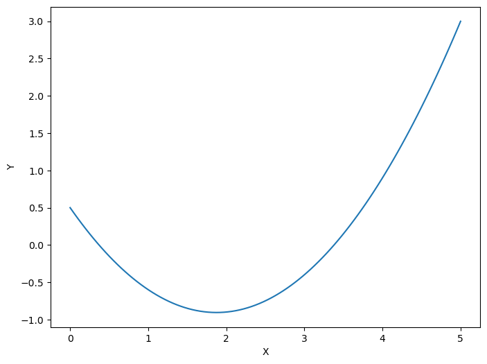

```python
X = np.linspace(0, 5, 100)
Y = 0.5 - 1.5 * X + 0.4 * X**2
plt.plot(X, Y)
plt.xlabel('X')
plt.ylabel('Y');
```

```python
act_min = X[Y.argmin()]  # actual argmin
print(act_min)
```

```
1.8686868686868687
```

1. Add a little noise to the function.

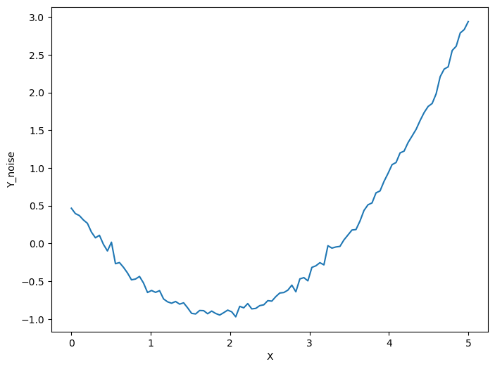

```python
np.random.seed(95)
Eps = np.random.normal(0, 0.05, size = len(X))
Y_noise = Y + Eps
plt.plot(X, Y_noise)
plt.xlabel('X')
plt.ylabel('Y_noise');
```

```python
obs_min = X[Y_noise.argmin(0)]  # observed (in contrast to actual) argmin
print(obs_min)
```

```
2.0707070707070705
```

Even a little noise may change minimum of the observed data.

1. Apply ideal regularizator to make search for minimum more stable: $$\alpha(X)=0.5-1.5 X +0.4 X^2,$$ where function $\alpha(X)$ is represented by variable `regularizator`.

```python
regularizator = 0.5 - 1.5 * X + 0.4 * X**2
```

This regularizator is ideal because it "knows" the exact function.

Select tuning parameter $\lambda$ represented by variable `tune` and minimize function $$Y(X)+\lambda \alpha(X)$$ instead of $Y(X)$.

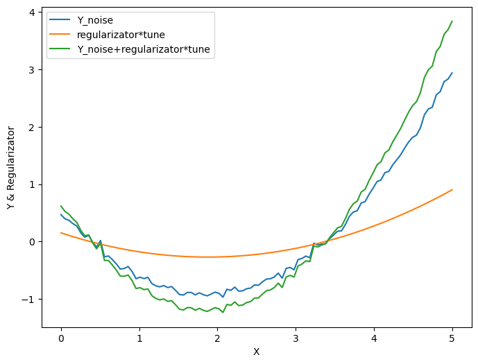

```python
tune = 0.3
plt.plot(X, Y_noise, label='Y_noise')
plt.plot(X, regularizator*tune, label='regularizator*tune')
plt.plot(X, Y_noise+regularizator*tune, label='Y_noise+regularizator*tune')
plt.xlabel('X')
plt.ylabel('Y & Regularizator')
plt.legend();
```

```python
reg_min = X[(Y_noise+regularizator*tune).argmin()]
print(reg_min)
```

```
2.0707070707070705
```

Setting tuning parameter to 0.3 did not help finding the real minimum of $Y(X)$.

Increase the tuning parameter to 1.

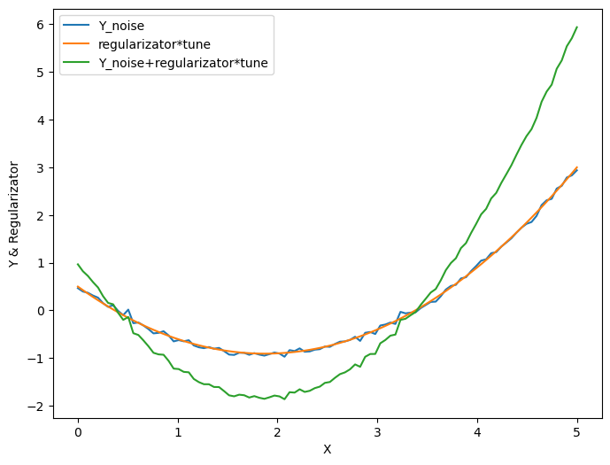

```python
tune = 1
plt.plot(X, Y_noise, label='Y_noise')
plt.plot(X, regularizator*tune, label='regularizator*tune')
plt.plot(X, Y_noise+regularizator*tune, label='Y_noise+regularizator*tune')
plt.xlabel('X')
plt.ylabel('Y & Regularizator')
plt.legend();
```

```python
reg_min = X[(Y_noise+regularizator*tune).argmin()]
print(reg_min)
```

```
2.0707070707070705
```

Still real minimum of $Y(X)$ is overestimated.

Increase tuning parameter to 3.

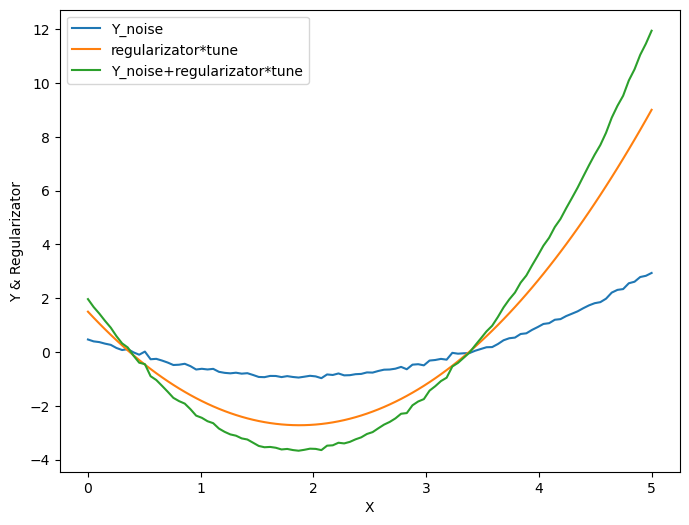

```python
tune = 3
plt.plot(X, Y_noise, label='Y_noise')
plt.plot(X, regularizator*tune, label='regularizator*tune')
plt.plot(X, Y_noise+regularizator*tune, label='Y_noise+regularizator*tune')
plt.xlabel('X')
plt.ylabel('Y & Regularizator')
plt.legend();
```

```python
reg_min = X[(Y_noise+regularizator*tune).argmin(0)]
print(reg_min)
```

```
1.8686868686868687
```

Now regularization worked: we recovered the actual minimum of the function.

But in real life we do not know ideal regularizator.
What if we set regularizator with a little shift in one of the coefficients?
Consider regularizator $$\alpha(X)= .5-1.5X+.3X^2,$$ changing the third coefficient to 0.3 instead of 0.4.

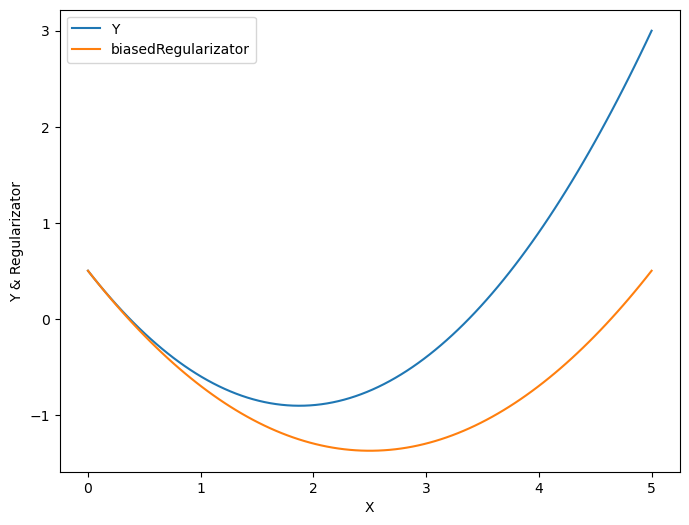

```python
biasedRegularizator = .5 - 1.5 * X + .3 * X**2
plt.plot(X, Y, label='Y')
plt.plot(X, biasedRegularizator, label='biasedRegularizator')
plt.xlabel('X')
plt.ylabel('Y & Regularizator')
plt.legend();
```

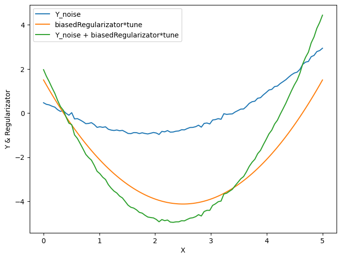

```python
plt.plot(X, Y_noise, label='Y_noise')
plt.plot(X, biasedRegularizator*tune, label='biasedRegularizator*tune')
plt.plot(X, Y_noise + biasedRegularizator*tune, label='Y_noise + biasedRegularizator*tune')
plt.xlabel('X')
plt.ylabel('Y & Regularizator')
plt.legend();
```

```python
biasedReg_min = X[(Y_noise+biasedRegularizator*tune).argmin(0)]
print(biasedReg_min)
```

```
2.323232323232323
```

**Lessons:**

1. Regularization is a very powerful method that allows using additional information about the solution of the problem.
2. If there is no significant additional information then regularization can be misleading.
3. When applied to regression without additional knowledge about parameters the problem of bias in the parameters and increased variance of their estimators is replaced by the same issues, but in regularizator.

# Lasso Regression

## Prostate data example

### Prepare the data

Read the data from prostate cancer study described in Elements of Statistical Learning: Data Mining, Inference and Prediction (second Edition), T.Hastie, R.Tibshirani, J. Friedman,2008, Springer.  
Data and other supplemental materials are on the [website of the book](http://statweb.stanford.edu/~tibs/ElemStatLearn/)

```python
prostateData = pd.read_csv("./data/prostatedata.csv")
prostateData.head()
```

|  | lcavol | lweight | age | lbph | svi | lcp | gleason | pgg45 | lpsa | train |
| --- | --- | --- | --- | --- | --- | --- | --- | --- | --- | --- |
| 0 | -0.579818 | 2.769459 | 50 | -1.386294 | 0 | -1.386294 | 6 | 0 | -0.430783 | T |
| 1 | -0.994252 | 3.319626 | 58 | -1.386294 | 0 | -1.386294 | 6 | 0 | -0.162519 | T |
| 2 | -0.510826 | 2.691243 | 74 | -1.386294 | 0 | -1.386294 | 7 | 20 | -0.162519 | T |
| 3 | -1.203973 | 3.282789 | 58 | -1.386294 | 0 | -1.386294 | 6 | 0 | -0.162519 | T |
| 4 | 0.751416 | 3.432373 | 62 | -1.386294 | 0 | -1.386294 | 6 | 0 | 0.371564 | T |

The goal of the study was to examine correlation between log of prostate-specific antigen `lpsa` as an output and some clinical measures:

- Log cancer volume `lcavol`
- Log prostate weight `lweight`
- Age `age`
- Log of the amount of benign prostatic hyperplasia `lbph`
- Seminal vehicle invasion `svi`
- Log of capsular penetration `lcp`
- Gleason score `gleason`
- percent of Gleason scores 4 or 5 `pgg45`

The last column in the file shows which rows were randomly selected for train sample and which for test sample.

Separate the train sub-sample and normalize the predictors.

```python
prostateData_norm = prostateData.iloc[:,:8]
prostateData_norm /= prostateData_norm.std()
prostateData_norm["lpsa"] = prostateData["lpsa"]
prostateData_norm["train"] = prostateData["train"]
prostateData_norm.head()
```

|  | lcavol | lweight | age | lbph | svi | lcp | gleason | pgg45 | lpsa | train |
| --- | --- | --- | --- | --- | --- | --- | --- | --- | --- | --- |
| 0 | -0.491945 | 6.464487 | 6.715811 | -0.955534 | 0.0 | -0.99145 | 8.308706 | 0.000000 | -0.430783 | T |
| 1 | -0.843570 | 7.748690 | 7.790341 | -0.955534 | 0.0 | -0.99145 | 8.308706 | 0.000000 | -0.162519 | T |
| 2 | -0.433408 | 6.281915 | 9.939400 | -0.955534 | 0.0 | -0.99145 | 9.693490 | 0.709118 | -0.162519 | T |
| 3 | -1.021506 | 7.662705 | 7.790341 | -0.955534 | 0.0 | -0.99145 | 8.308706 | 0.000000 | -0.162519 | T |
| 4 | 0.637536 | 8.011865 | 8.327606 | -0.955534 | 0.0 | -0.99145 | 8.308706 | 0.000000 | 0.371564 | T |

```python
print(prostateData_norm.iloc[:,:8].std())
```

```
lcavol     1.0
lweight    1.0
age        1.0
lbph       1.0
svi        1.0
lcp        1.0
gleason    1.0
pgg45      1.0
dtype: float64
```

```python
prostateData_norm_train = prostateData_norm[prostateData_norm["train"] == "T"].drop(columns='train')
prostateData_norm_train.head()
```

|  | lcavol | lweight | age | lbph | svi | lcp | gleason | pgg45 | lpsa |
| --- | --- | --- | --- | --- | --- | --- | --- | --- | --- |
| 0 | -0.491945 | 6.464487 | 6.715811 | -0.955534 | 0.0 | -0.99145 | 8.308706 | 0.000000 | -0.430783 |
| 1 | -0.843570 | 7.748690 | 7.790341 | -0.955534 | 0.0 | -0.99145 | 8.308706 | 0.000000 | -0.162519 |
| 2 | -0.433408 | 6.281915 | 9.939400 | -0.955534 | 0.0 | -0.99145 | 9.693490 | 0.709118 | -0.162519 |
| 3 | -1.021506 | 7.662705 | 7.790341 | -0.955534 | 0.0 | -0.99145 | 8.308706 | 0.000000 | -0.162519 |
| 4 | 0.637536 | 8.011865 | 8.327606 | -0.955534 | 0.0 | -0.99145 | 8.308706 | 0.000000 | 0.371564 |

```python
print('Train size =', prostateData_norm_train.shape[0])
```

```
Train size = 67
```

```python
prostateData_norm_test = prostateData_norm[prostateData_norm["train"] == "F"].drop(columns='train')
prostateData_norm_test.head()
```

|  | lcavol | lweight | age | lbph | svi | lcp | gleason | pgg45 | lpsa |
| --- | --- | --- | --- | --- | --- | --- | --- | --- | --- |
| 6 | 0.625444 | 8.107906 | 8.596238 | 0.424030 | 0.0 | -0.991450 | 8.308706 | 0.000000 | 0.765468 |
| 8 | -0.658843 | 8.261943 | 6.312862 | -0.955534 | 0.0 | -0.991450 | 8.308706 | 0.000000 | 1.047319 |
| 9 | 0.189325 | 7.573434 | 8.461922 | -0.955534 | 0.0 | -0.991450 | 8.308706 | 0.000000 | 1.047319 |
| 14 | 1.023202 | 8.034381 | 7.656025 | -0.955534 | 0.0 | -0.308087 | 9.693490 | 0.177280 | 1.398717 |
| 21 | 1.747154 | 8.172155 | 8.058973 | 1.016512 | 0.0 | 0.964115 | 9.693490 | 0.709118 | 1.658228 |

```python
print('Test size =', prostateData_norm_test.shape[0])
```

```
Test size = 30
```

```python
X_train = prostateData_norm_train.drop(columns=['lpsa'])
y_train = prostateData_norm_train['lpsa']
X_test = prostateData_norm_test.drop(columns=['lpsa'])
y_test = prostateData_norm_test['lpsa']
```

### Fitting linear model

Fit linear model.

```python
import statsmodels.api as sm

allPredictors_lm = sm.OLS(y_train, sm.add_constant(X_train)).fit()
print(allPredictors_lm.summary())
```

```
                            OLS Regression Results
==============================================================================
Dep. Variable:                   lpsa   R-squared:                       0.694
Model:                            OLS   Adj. R-squared:                  0.652
Method:                 Least Squares   F-statistic:                     16.47
Date:                Sat, 11 Feb 2023   Prob (F-statistic):           2.04e-12
Time:                        17:25:24   Log-Likelihood:                -67.505
No. Observations:                  67   AIC:                             153.0
Df Residuals:                      58   BIC:                             172.9
Df Model:                           8
Covariance Type:            nonrobust
==============================================================================
                 coef    std err          t      P>|t|      [0.025      0.975]
------------------------------------------------------------------------------
const          0.4292      1.554      0.276      0.783      -2.681       3.539
lcavol         0.6795      0.127      5.366      0.000       0.426       0.933
lweight        0.2631      0.096      2.751      0.008       0.072       0.454
age           -0.1415      0.101     -1.396      0.168      -0.344       0.061
lbph           0.2101      0.102      2.056      0.044       0.006       0.415
svi            0.3052      0.124      2.469      0.017       0.058       0.553
lcp           -0.2885      0.155     -1.867      0.067      -0.598       0.021
gleason       -0.0213      0.145     -0.147      0.884      -0.312       0.269
pgg45          0.2670      0.154      1.738      0.088      -0.041       0.574
==============================================================================
Omnibus:                        0.825   Durbin-Watson:                   1.690
Prob(Omnibus):                  0.662   Jarque-Bera (JB):                0.389
Skew:                          -0.164   Prob(JB):                        0.823
Kurtosis:                       3.178   Cond. No.                         277.
==============================================================================

Notes:
[1] Standard Errors assume that the covariance matrix of the errors is correctly specified.
```

We see several significant predictors: `lcavol`, `lweight`, `svi` and two barely significant predictors `lcp` and `lbph`.  
Predictors `gleason` and `age` do not appear to be significant at all.

Check correlations between predictors.

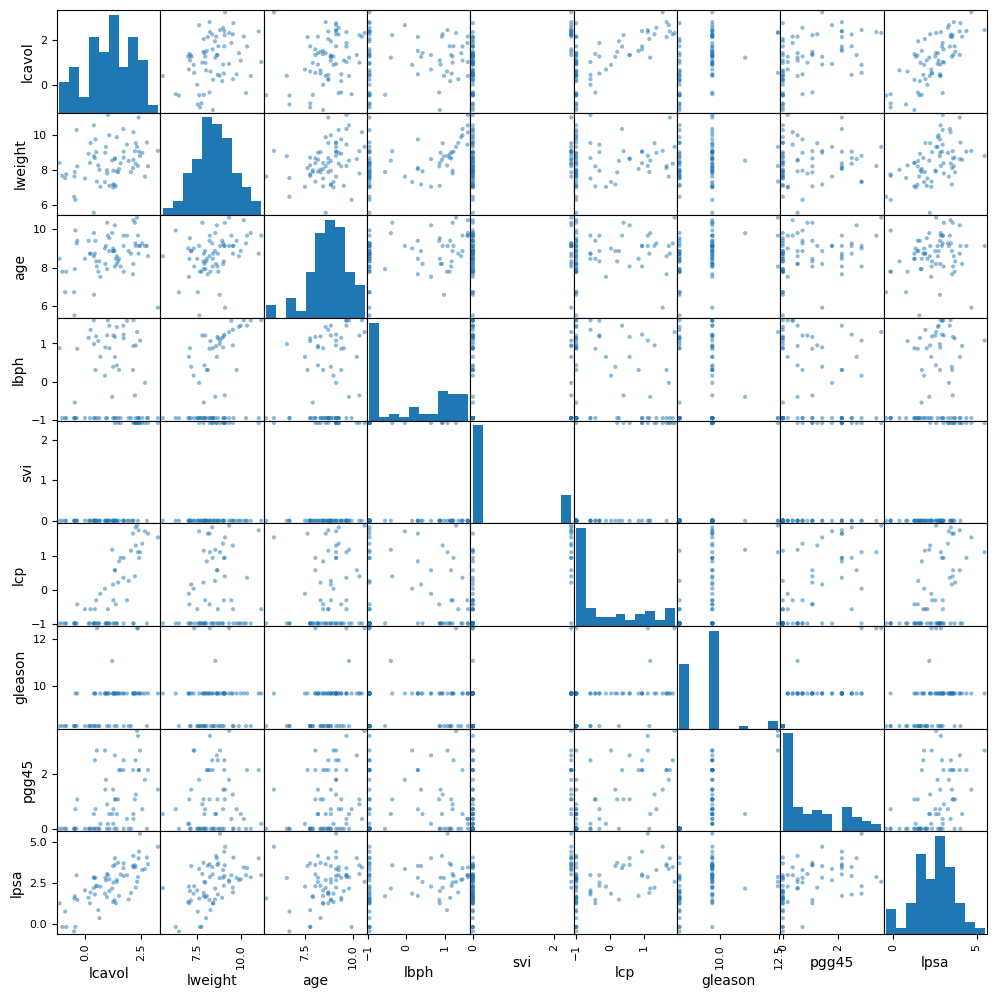

```python
pairs = pd.plotting.scatter_matrix(prostateData_norm_train, figsize=(12,12))
```

```python
print(X_train.corr().round(3))
```

```
         lcavol  lweight    age   lbph    svi    lcp  gleason  pgg45
lcavol    1.000    0.300  0.286  0.063  0.593  0.692    0.426  0.483
lweight   0.300    1.000  0.317  0.437  0.181  0.157    0.024  0.074
age       0.286    0.317  1.000  0.287  0.129  0.173    0.366  0.276
lbph      0.063    0.437  0.287  1.000 -0.139 -0.089    0.033 -0.030
svi       0.593    0.181  0.129 -0.139  1.000  0.671    0.307  0.481
lcp       0.692    0.157  0.173 -0.089  0.671  1.000    0.476  0.663
gleason   0.426    0.024  0.366  0.033  0.307  0.476    1.000  0.757
pgg45     0.483    0.074  0.276 -0.030  0.481  0.663    0.757  1.000
```

```python
print((X_train.corr() ** 2).round(3))
```

```
         lcavol  lweight    age   lbph    svi    lcp  gleason  pgg45
lcavol    1.000    0.090  0.082  0.004  0.352  0.479    0.182  0.233
lweight   0.090    1.000  0.100  0.191  0.033  0.025    0.001  0.006
age       0.082    0.100  1.000  0.083  0.017  0.030    0.134  0.076
lbph      0.004    0.191  0.083  1.000  0.019  0.008    0.001  0.001
svi       0.352    0.033  0.017  0.019  1.000  0.451    0.094  0.232
lcp       0.479    0.025  0.030  0.008  0.451  1.000    0.227  0.439
gleason   0.182    0.001  0.134  0.001  0.094  0.227    1.000  0.573
pgg45     0.233    0.006  0.076  0.001  0.232  0.439    0.573  1.000
```

```python
print(X_train.corr() ** 2 >.5)
```

```
         lcavol  lweight    age   lbph    svi    lcp  gleason  pgg45
lcavol     True    False  False  False  False  False    False  False
lweight   False     True  False  False  False  False    False  False
age       False    False   True  False  False  False    False  False
lbph      False    False  False   True  False  False    False  False
svi       False    False  False  False   True  False    False  False
lcp       False    False  False  False  False   True    False  False
gleason   False    False  False  False  False  False     True   True
pgg45     False    False  False  False  False  False     True   True
```

Matrix of determination coefficients shows that there is one significant determination coefficient (>0.5) between predictors: $\rho^2(ppg45,gleason)=0.573$.  
The other three noticeable determination coefficients are $\rho^2(lcp,lcavol)=0.479$, $\rho^2(lcp,svi)=0.45$ and $\rho^2(lcp,pgg45)=0.439.$

Correlations between predictors make selection of predictors difficult.  
For example, predictor `lcp` is correlated with `lcavol`, `svi` and `pgg45`.  
In the presence of all predictors `svi` is significant with 5% level, but `lcp` is not.

```python
print(allPredictors_lm.pvalues > 0.05)
```

```
const       True
lcavol     False
lweight    False
age         True
lbph       False
svi        False
lcp         True
gleason     True
pgg45       True
dtype: bool
```

But after removal of `lcp` predictor `svi` becomes insignificant.

```python
nolcp_lm = sm.OLS(y_train,
                  sm.add_constant(X_train.drop(columns='lcp'))).fit()
print(nolcp_lm.pvalues > 0.05)
```

```
const       True
lcavol     False
lweight    False
age         True
lbph       False
svi         True
gleason     True
pgg45       True
dtype: bool
```

This is a big challenge for any greedy algorithm.

Consider removing all insignificant predictors: `age`, `lcp`, `gleason` and `pgg45`.

We can test significance of groups of predictors by using F-statistic $$F=\frac{(RSS_0-RSS_1)/(p_1-p_0)}{RSS_1/(N-p_1-1)},$$ where $RSS_1$ is the residual sum of squares of bigger model including all $p_1+1$ parameters $\beta_0,\beta_1,\ldots,\beta_{p_1}$; $RSS_0$ is the residual sum of squares of the model that has only $p_0+1$ parameters not equal to zero and the rest $p_1-p_0$ parameters equal to zero: $\beta_0,\beta_1,\ldots,\beta_{p_0},\beta_{p_0+1}=0,\ldots,\beta_{p_1}=0$.
Such F-statistic measures significance of change in sum of squares of the bigger model if a group of predictors gets eliminated.
Under $H_0:\beta_{p_0+1}=0,\ldots,\beta_{p_1}=0$ the statistic has F-distribution: $F \sim F_{p_1-p_0,N-{p_1}-1}$.

```python
significantPredictors_lm = sm.OLS(y_train,
                           sm.add_constant(X_train.drop(['age','lcp', 'gleason', 'pgg45'],axis=1))).fit()
RSS1 = np.sum(allPredictors_lm.resid**2)
print('RSS1 =', RSS1)
RSS0 = np.sum(significantPredictors_lm.resid**2)
print('RSS0 =', RSS0)
```

```
RSS1 = 29.42638445990839
RSS0 = 32.81499474881556
```

```python
statisticF = (RSS0-RSS1)/(8-4) / (RSS1/(67-8-1))
print(statisticF)
```

```
1.6697548846375292
```

```python
import scipy.stats as stats

print(stats.f.sf(statisticF, 8-4, 67-8-1))  # sf == 1-cdf
```

```
0.16933707265224937
```

This shows that p-value is large and $H_0:\beta_{p_0+1}=0,\ldots,\beta_{p_1}=0$ cannot be rejected.

Check assumptions of the model and mean square error of prediction of `significantPredictors_lm`.

```python
print(significantPredictors_lm.summary())
```

```
                            OLS Regression Results
==============================================================================
Dep. Variable:                   lpsa   R-squared:                       0.659
Model:                            OLS   Adj. R-squared:                  0.637
Method:                 Least Squares   F-statistic:                     29.98
Date:                Sat, 11 Feb 2023   Prob (F-statistic):           6.91e-14
Time:                        17:25:26   Log-Likelihood:                -71.156
No. Observations:                  67   AIC:                             152.3
Df Residuals:                      62   BIC:                             163.3
Df Model:                           4
Covariance Type:            nonrobust
==============================================================================
                 coef    std err          t      P>|t|      [0.025      0.975]
------------------------------------------------------------------------------
const         -0.3259      0.780     -0.418      0.677      -1.885       1.233
lcavol         0.5958      0.109      5.461      0.000       0.378       0.814
lweight        0.2308      0.095      2.441      0.018       0.042       0.420
lbph           0.2031      0.102      1.988      0.051      -0.001       0.407
svi            0.2781      0.113      2.459      0.017       0.052       0.504
==============================================================================
Omnibus:                        0.907   Durbin-Watson:                   1.800
Prob(Omnibus):                  0.635   Jarque-Bera (JB):                0.732
Skew:                          -0.254   Prob(JB):                        0.694
Kurtosis:                       2.940   Cond. No.                         77.0
==============================================================================

Notes:
[1] Standard Errors assume that the covariance matrix of the errors is correctly specified.
```

Note that `lbph` is still not significant with 5% level.

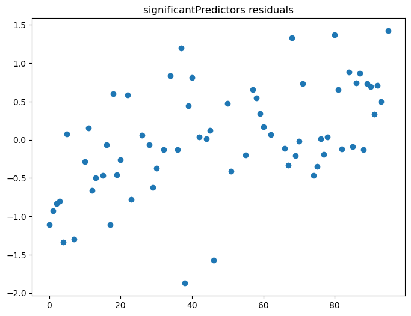

```python
plt.plot(significantPredictors_lm.resid, 'o')
plt.title('significantPredictors residuals');
```

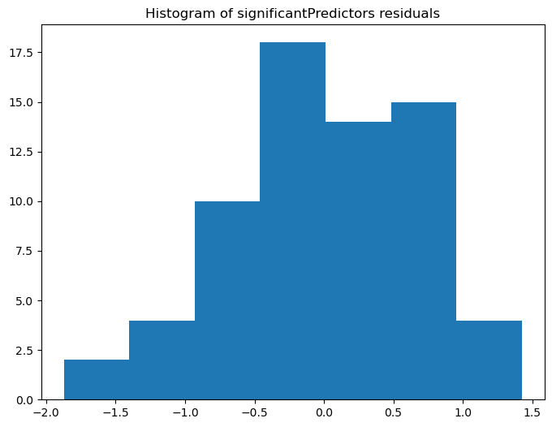

```python
plt.hist(significantPredictors_lm.resid, bins=7)
plt.title('Histogram of significantPredictors residuals');
```

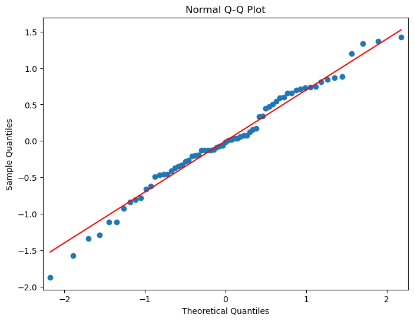

```python
sm.qqplot(significantPredictors_lm.resid, line='s')
plt.title('Normal Q-Q Plot');
```

```python
print(significantPredictors_lm.aic)
```

```
152.31269099964987
```

```python
print(allPredictors_lm.aic)
```

```
153.01010201797789
```

```python
from sklearn import linear_model

significantPredictors_lm2 = linear_model.LinearRegression()
significantPredictors_lm2.fit(X_train.drop(['age','lcp', 'gleason', 'pgg45'],axis=1), y_train)
testPredict = significantPredictors_lm2.predict(X_test.drop(['age','lcp', 'gleason', 'pgg45'],axis=1))
MSE_significantPredictors = np.mean((y_test-testPredict)**2)
print(MSE_significantPredictors)
```

```
0.4563321220401625
```

```python
allPredictors_lm2 = linear_model.LinearRegression()
allPredictors_lm2.fit(X_train, y_train)
testPredict = allPredictors_lm2.predict(X_test)
MSE_allPredictors = np.mean((y_test-testPredict)**2)
print(MSE_allPredictors)
```

```
0.5212740055076002
```

```python
# model without predictors (just intercept)
testPredict_mean = np.mean(y_train)
MSE_meanPredictor = np.mean((y_test-testPredict_mean)**2)
print(MSE_meanPredictor)
```

```
1.0567332280603818
```

Using both AIC and mean square prediction error as measures of goodness of fit we show that the model with only significant predictors is better than the model with all predictors.

### Lasso regression model

Fit lasso regression model to train data using `glmnet` package. Currently only the 64-bit linux version is supported for Python. A working Fortran compiler is required to build the package for Windows.

```python
import glmnet

lassoProstate = glmnet.ElasticNet(alpha=1, scoring='mean_squared_error',
                                  n_splits=10, standardize=False)
lassoProstate.fit(X_train, y_train)
```

```
ElasticNet(n_splits=10, scoring='mean_squared_error', standardize=False)
```

The following plot shows trajectories of coefficients as $L_1$-norm changes, where $L_1$-norm is $|| \mathbf{\beta}||=\sum_i |\beta_i|$.

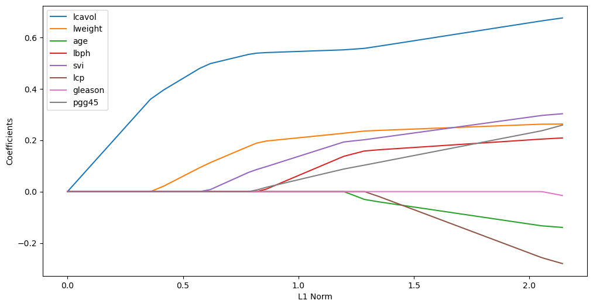

```python
l1_norm = np.sum(np.abs(lassoProstate.coef_path_), axis=0)

plt.figure(figsize=(12,6))
plt.plot(l1_norm, lassoProstate.coef_path_.T)
plt.xlabel("L1 Norm")
plt.ylabel("Coefficients")
plt.legend(X_train.columns);
```

The graph shows how coefficients become small and turn into zeros as $L_1$-norm decreases.

Next, use cross validation to find the best level of $\lambda$.  
Parameter `alpha` defines the model: `alpha=0` for ridge regression, `alpha=1` - for lasso regression.

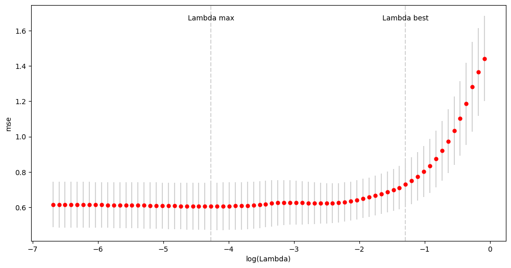

```python
plt.figure(figsize=(12,6))
plt.errorbar(np.log(lassoProstate.lambda_path_), -lassoProstate.cv_mean_score_, color='r', linestyle='None', marker='o',
             markersize=5, yerr=lassoProstate.cv_standard_error_, ecolor='lightgrey', capthick=2)
plt.axvline(x=np.log(lassoProstate.lambda_max_), linestyle='dashed', color='lightgrey')
plt.text(np.log(lassoProstate.lambda_max_), .95*plt.gca().get_ylim()[1], 'Lambda max', ha='center')
plt.axvline(x=np.log(lassoProstate.lambda_best_), linestyle='dashed', color='lightgrey')
plt.text(np.log(lassoProstate.lambda_best_), .95*plt.gca().get_ylim()[1], 'Lambda best', ha='center')
plt.ylabel('mse');
plt.xlabel('log(Lambda)');
```

The plot shows how mean square error changes with $\lambda$.  
Vertical intervals are standard deviation bounds for mean square error.  
Left vertical dashed line shows the best parameter $\lambda$, the vertical dashed line on the right is one standard deviation away.  
The best $\lambda$ is returned in `lambda_max_`.

We see that standard errors of each MSE coded by red dots are pretty wide and the difference between $\lambda_{max}$ and $\lambda_{max}+\sigma_{\lambda}$ is pretty wide also.  
These are the signs that model may not be working very well for this data set.

```python
bestlam = lassoProstate.lambda_max_
print(bestlam)
```

```
0.013977674273137676
```

Predict the output of the test sample using the model fitted to the train sample and calculate mean square prediction error.

```python
lasso_pred = lassoProstate.predict(X_test, lamb=bestlam)
MSE_lasso = np.mean((lasso_pred - y_test)**2)
print(MSE_lasso)
```

```
0.49239893456323014
```

Find lasso coefficients and compare them with the coefficients of linear model

```python
l_coef = pd.DataFrame(allPredictors_lm.params, columns=["Lm"])
l_coef["Lasso"]= np.append(lassoProstate.intercept_, lassoProstate.coef_)
l_coef
```

|  | Lm | Lasso |
| --- | --- | --- |
| const | 0.429170 | 0.605844 |
| lcavol | 0.679528 | 0.517441 |
| lweight | 0.263053 | 0.147199 |
| age | -0.141465 | 0.000000 |
| lbph | 0.210147 | 0.000000 |
| svi | 0.305201 | 0.044287 |
| lcp | -0.288493 | 0.000000 |
| gleason | -0.021305 | 0.000000 |
| pgg45 | 0.266956 | 0.000000 |

Compare mean square prediction errors:

```python
print("Null   = ", MSE_meanPredictor)
print("Linear = ", MSE_allPredictors)
print("Linear'= ", MSE_significantPredictors)
print("Lasso  = ", MSE_lasso)
```

```
Null   =  1.0567332280603818
Linear =  0.5212740055076002
Linear'=  0.4563321220401625
Lasso  =  0.49239893456323014
```

### PCA

Apply the PCA method to the same data.  
The final outputs below are obtained using 5 PCA factors as predictors in linear model.

```python
from sklearn.decomposition import PCA

prostateData_PCA = PCA()
prostateData_PCA.fit(X_train)
prostateData_PCA_summary = pd.DataFrame({'Standard deviation': np.sqrt(prostateData_PCA.explained_variance_),
                               'Proportion of Variance': prostateData_PCA.explained_variance_ratio_,
                               'Cumulative Proportion': np.cumsum(prostateData_PCA.explained_variance_ratio_)},
                               columns=['Standard deviation','Proportion of Variance','Cumulative Proportion'],
                               index=[ "Comp.%i" %(i+1) for i in range(prostateData_PCA.n_components_)])
print('PCA summary:')
prostateData_PCA_summary.T
```

```
PCA summary:
```

|  | Comp.1 | Comp.2 | Comp.3 | Comp.4 | Comp.5 | Comp.6 | Comp.7 | Comp.8 |
| --- | --- | --- | --- | --- | --- | --- | --- | --- |
| Standard deviation | 1.892414 | 1.336453 | 1.040685 | 0.793937 | 0.716864 | 0.632754 | 0.531816 | 0.424457 |
| Proportion of Variance | 0.423415 | 0.211175 | 0.128048 | 0.074526 | 0.060759 | 0.047337 | 0.033439 | 0.021301 |
| Cumulative Proportion | 0.423415 | 0.634590 | 0.762638 | 0.837164 | 0.897922 | 0.945260 | 0.978699 | 1.000000 |

```python
nFactors = 8
factorLoadings = pd.DataFrame(prostateData_PCA.components_[:nFactors, :],
                              columns= X_train.columns,
                              index=[ "Comp.%i" %(i+1) for i in range(nFactors)])
factors_train  = pd.DataFrame(prostateData_PCA.transform(X_train)[:, :nFactors],
                              columns =["Comp.%i" %(i+1) for i in range(nFactors)],
                              index=X_train.index)
zeroLoading = prostateData_PCA.mean_
```

```python
def rel_imp_me(X, y):
    names = X.columns
    ser = pd.Series(index = names, dtype='float64')
    lm0 = sm.OLS(y, sm.add_constant(X)).fit()
    for c in names:
        lm = sm.OLS(y, sm.add_constant(X[names.drop(c)])).fit()
        ser[c] = lm0.rsquared - lm.rsquared
    res = pd.DataFrame(columns =['last', 'first', 'betasq', 'pratt'], index=names)
    res['last'] = ser
    corr = X.apply(lambda x: np.corrcoef(y,x)[0,1], axis=0)
    res['first'] = corr**2
    sx = X.apply(np.std, axis=0)
    res['betasq'] = (lm0.params[names] * sx / np.std(y))**2
    res['pratt'] = (lm0.params[names] * sx / np.std(y)) * corr
    return res


metrics_PCA = rel_imp_me(factors_train, y_train)
print('Relative importance measures:')
metrics_PCA
```

```
Relative importance measures:
```

|  | last | first | betasq | pratt |
| --- | --- | --- | --- | --- |
| Comp.1 | 0.472279 | 0.472279 | 0.472279 | 0.472279 |
| Comp.2 | 0.059002 | 0.059002 | 0.059002 | 0.059002 |
| Comp.3 | 0.067062 | 0.067062 | 0.067062 | 0.067062 |
| Comp.4 | 0.013332 | 0.013332 | 0.013332 | 0.013332 |
| Comp.5 | 0.007201 | 0.007201 | 0.007201 | 0.007201 |
| Comp.6 | 0.007755 | 0.007755 | 0.007755 | 0.007755 |
| Comp.7 | 0.039376 | 0.039376 | 0.039376 | 0.039376 |
| Comp.8 | 0.028364 | 0.028364 | 0.028364 | 0.028364 |

```python
first_PCA_rank = metrics_PCA['first'].rank(ascending=False)
metrics_PCA_sort = pd.DataFrame({"Predictors": first_PCA_rank.index,
                                 "Rank": first_PCA_rank.values}).sort_values(by="Rank")
orderedFactors_train = pd.DataFrame(factors_train, columns=metrics_PCA_sort["Predictors"])
orderedLoadings = pd.DataFrame(factorLoadings.T, columns=metrics_PCA_sort["Predictors"])
print('Ordered factors for train data (head):')
orderedFactors_train.head()
```

```
Ordered factors for train data (head):
```

| Predictors | Comp.1 | Comp.3 | Comp.2 | Comp.7 | Comp.8 | Comp.4 | Comp.6 | Comp.5 |
| --- | --- | --- | --- | --- | --- | --- | --- | --- |
| 0 | -3.028275 | 0.281548 | -2.160859 | -0.015615 | 0.050018 | 0.564205 | -0.384151 | -0.109482 |
| 1 | -2.672572 | 0.198010 | -0.957099 | -0.245040 | 0.183593 | -0.183459 | -0.572525 | 0.715095 |
| 2 | -1.435018 | -2.092668 | -1.374674 | -0.031096 | 0.188689 | -1.419275 | -0.692812 | -0.189325 |
| 3 | -2.770835 | 0.118565 | -1.017178 | -0.290276 | 0.226749 | -0.172573 | -0.693956 | 0.741656 |
| 4 | -1.816898 | 0.465864 | -0.555113 | 0.033897 | -0.214758 | -0.693150 | 0.301580 | 0.144358 |

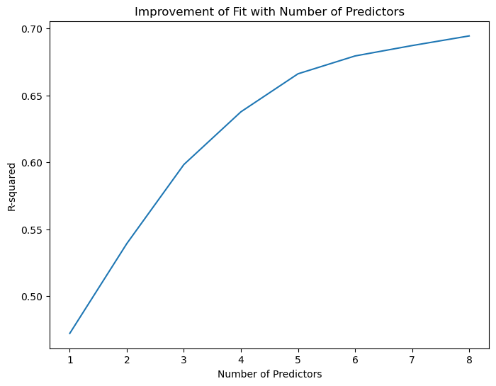

```python
orderedPCA_R2 = [sm.OLS(y_train, sm.add_constant(orderedFactors_train.iloc[:,:j])).fit().rsquared \
                 for j in range(1, nFactors+1)]
plt.plot(range(1, nFactors+1),orderedPCA_R2)

plt.title("Improvement of Fit with Number of Predictors")
plt.ylabel("R-squared")
plt.xlabel("Number of Predictors");
```

```python
m5_PCA = sm.OLS(y_train, sm.add_constant(orderedFactors_train.iloc[:,:5])).fit()
coefficients_PCA = m5_PCA.params
restoredSlopes = np.dot(orderedLoadings.iloc[:,:5], coefficients_PCA[1:6])
```

Compare coefficients returned by the lasso regression, linear model and PCA methods.

```python
coefficientsComparison = pd.DataFrame({'Lasso': lassoProstate.coef_,
                                       'Lm' : allPredictors_lm.params[1:9],
                                       'PCR' : restoredSlopes},
                                      index=X_train.columns)
print('Slopes estimates for different models:')
coefficientsComparison
```

```
Slopes estimates for different models:
```

|  | Lasso | Lm | PCR |
| --- | --- | --- | --- |
| lcavol | 0.517441 | 0.679528 | 0.524795 |
| lweight | 0.147199 | 0.263053 | 0.323933 |
| age | 0.000000 | -0.141465 | -0.003454 |
| lbph | 0.000000 | 0.210147 | 0.093070 |
| svi | 0.044287 | 0.305201 | 0.434445 |
| lcp | 0.000000 | -0.288493 | -0.322243 |
| gleason | 0.000000 | -0.021305 | -0.054507 |
| pgg45 | 0.000000 | 0.266956 | 0.281250 |

PCR method used all original predictors, but if the number of factors is reduced to 5 the regression problem in fact has smaller number of predictors to fit.  
If all PCA factors are used as predictors then coefficients are expected to be the same as coefficients of the linear model.

Calculate MSE for PCR method:

1. With the test data calculate test metafeatures using definition of factors in PCR: $$F=X_0 L$$ where
   - $X_0$ is the test matrix of the original features centered by the zero loading of the PCA model fitted to the train feature matrix
   - $L$ is the matrix of loadings of the PCA model fitted to the train feature matrix
2. Reorder test metafeatures in the order of relative importance of factors of the PCA model fitted to the original features
3. Predict test responce sample with the linear model containing the best 5 train metafeatures using test metafeatures as new data
4. Calculate MSE of the PCR model

```python
factors_test = pd.DataFrame(prostateData_PCA.transform(X_test)[:, :nFactors],
                            columns =["Comp.%i" %(i+1) for i in range(nFactors)],
                            index=X_test.index)
orderedFactors_test = pd.DataFrame(factors_test, columns=orderedFactors_train.columns)
pcr5_lm2 = linear_model.LinearRegression()
pcr5_lm2.fit(orderedFactors_train.iloc[:,:5], y_train)
testPredict = pcr5_lm2.predict(orderedFactors_test.iloc[:,:5])
MSE_pcr5 = np.mean((y_test-testPredict)**2)
```

```python
print('MSE on test data:')
print("Null   = ", MSE_meanPredictor)
print("Linear = ", MSE_allPredictors)
print("Linear'= ", MSE_significantPredictors)
print("Lasso  = ", MSE_lasso)
print("PCR    = ", MSE_pcr5)
```

```
MSE on test data:
Null   =  1.0567332280603818
Linear =  0.5212740055076002
Linear'=  0.4563321220401625
Lasso  =  0.49239893456323014
PCR    =  0.5755578082150292
```

# Using Ridge and Lasso regression with the data from Workshop 1 from week 1

## Simulation of the data

In this experiment simulate a series of nested linear models with large number of independent predictors.
The model is: $$Y_{i,j} = \beta_0 + \beta_1 X_{i,1} + \ldots + \beta_{i,j} + \epsilon_i;~~i=1,\ldots,500;~~j=2,\ldots,500. $$ So, the first model of the series, $j=2$ is $$Y_{i,2} = \beta_0 + \beta_1 X_{i,1} + \beta_2 X_{i,2} + \epsilon_i;~~i=1,\ldots,500.$$ And the last model of the series, $j=500$ is $$Y_{i,500} = \beta_0 + \beta_1 X_{i,1} + \ldots + \beta_{i,500} + \epsilon_i;~~i=1,\ldots,500.$$ All nested models have the same vector of residuals $\epsilon_i;~~i=1,\ldots,500;\epsilon_i \sim Norm(0,1)$.
All 500 predictors $X_{i,j};~~j=1,\ldots,500$ are independent samples from $Norm(0,2).$
Slopes of the predictors are randomly selected from uniform distribution on $[1,3]$.

```python
np.random.seed(1234567)

Epsilon = np.random.normal(0,1, size=500)
colnames = [ "X%i" %(j+1) for j in range(500)]
X = pd.DataFrame(np.random.normal(0,2, size=(500, 500)), columns=colnames)
slopesSet = np.random.uniform(low=1, high=3, size=500)

Y = np.column_stack([1 + np.dot(X.iloc[:, :j], slopesSet[:j]) + Epsilon for j in range(2, 501)])
```

## Fitting linear models

Fit linear model with the first 10 predictors.

```python
m10 = sm.OLS(Y[:,8],sm.add_constant(X.iloc[:,:10])).fit()
#print(m10.summary())
```

Fit linear model with 491 predictors.

```python
m491 = sm.OLS(Y[:,489],sm.add_constant(X.iloc[:,:491])).fit()
#print(m491.summary())
```

## Ridge regression

Apply ridge regression to the data with 10 predictors.

```python
ridge10 = glmnet.ElasticNet(alpha=0, n_lambda=200, scoring='mean_squared_error',
                            n_splits=10, standardize=False)
```

Separate the sample into `train` and `test`.

```python
from sklearn.model_selection import train_test_split

X_train, X_test, y_train, y_test = train_test_split(X.iloc[:,:10], Y[:,8],
                                                    test_size=0.5, random_state=1)
```

Select the best parameter $\lambda$ using cross validation on train set.

Use the default ten-fold cross validation.

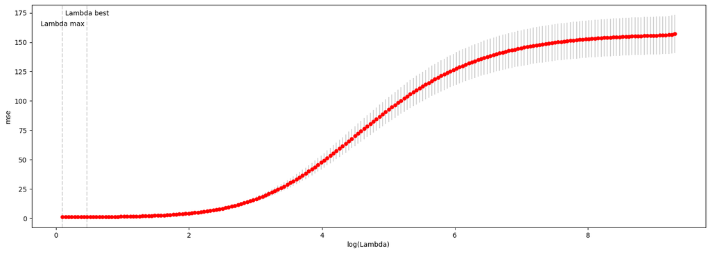

```python
ridge10.fit(X_train, y_train)
plt.figure(figsize=(18,6))
plt.errorbar(np.log(ridge10.lambda_path_), -ridge10.cv_mean_score_, color='r', linestyle='None', marker='o',
             markersize=5, yerr=ridge10.cv_standard_error_, ecolor='lightgrey', capthick=2)
plt.axvline(x=np.log(ridge10.lambda_best_), linestyle='dashed', color='lightgrey')
plt.text(np.log(ridge10.lambda_best_), .95*plt.gca().get_ylim()[1], 'Lambda best', ha='center')
plt.axvline(x=np.log(ridge10.lambda_max_), linestyle='dashed', color='lightgrey')
plt.text(np.log(ridge10.lambda_max_), .9*plt.gca().get_ylim()[1], 'Lambda max', ha='center')
plt.ylabel('mse')
plt.xlabel('log(Lambda)');
```

```python
bestlam = ridge10.lambda_max_
bestlam
```

```
1.1034648434266965
```

Calculate mean squared prediction error for the best selected $\lambda=$ `bestlam`.

```python
ridge_pred = ridge10.predict(X_test, lamb = bestlam)
ridge_MSE = np.mean((ridge_pred-y_test)**2)
print(ridge_MSE)
```

```
1.1271073850645994
```

Compare the mean squared prediction error

```python
train_m10 = sm.OLS(y_train, sm.add_constant(X_train)).fit()
lm_pred = train_m10.predict(sm.add_constant(X_test))
lm_MSE = np.mean((lm_pred - y_test)**2)
print(lm_MSE)
```

```
1.1847964803464626
```

Ridge regression did not select predictors. It is expected because we simulated all predictors to be significant.  
Ridge regression made a small improvement to mean squared prediction error. This is consistent with expectation because it has one additional parameter.

Regularization is expected to reduce number of predictors when there are collinear (highly correlated) predictors.  
Predictors in this example are not collinear.

## Lasso regression

Fit lasso regression to the first 10 predictors.

```python
lasso10 = glmnet.ElasticNet(alpha=1, n_lambda=200, scoring='mean_squared_error',
                            n_splits=10, standardize=False)
lasso10.fit(X_train, y_train)
```

```
ElasticNet(n_lambda=200, n_splits=10, scoring='mean_squared_error',
           standardize=False)
```

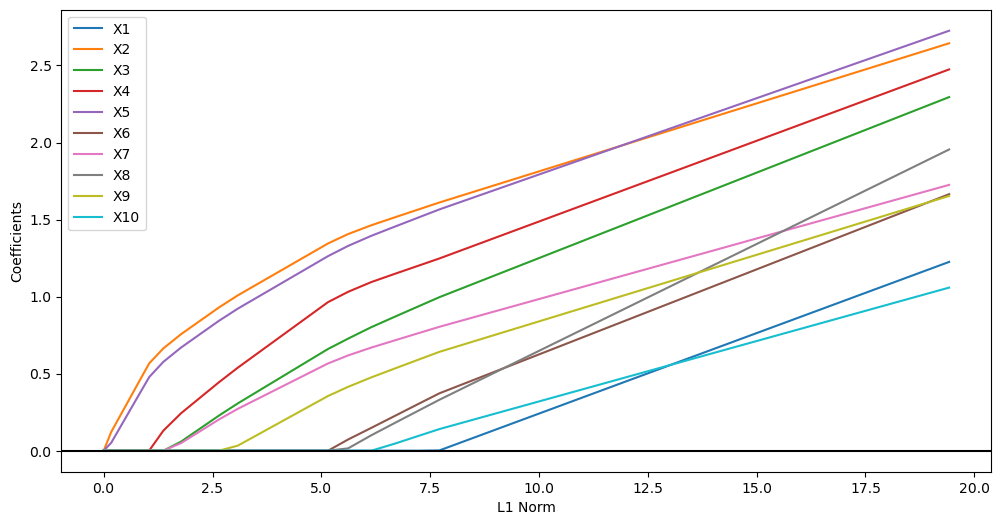

```python
l1_norm = np.sum(np.abs(lasso10.coef_path_), axis=0)

plt.figure(figsize=(12,6))
plt.plot(l1_norm, lasso10.coef_path_.T)
plt.axhline(y = 0, color='k')
plt.xlabel("L1 Norm")
plt.ylabel("Coefficients")
plt.legend(X_train.columns);
```

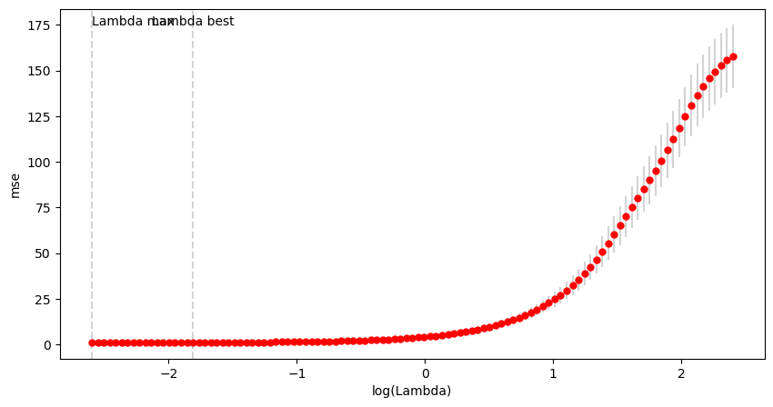

```python
plt.figure(figsize=(10,5))
plt.errorbar(np.log(lasso10.lambda_path_), -lasso10.cv_mean_score_, color='r', linestyle='None', marker='o',
             markersize=5, yerr=lasso10.cv_standard_error_, ecolor='lightgrey', capthick=2)
plt.axvline(x=np.log(lasso10.lambda_max_), linestyle='dashed', color='lightgrey')
plt.text(np.log(lasso10.lambda_max_), .95*plt.gca().get_ylim()[1], 'Lambda max', ha='left')
plt.axvline(x=np.log(lasso10.lambda_best_), linestyle='dashed', color='lightgrey')
plt.text(np.log(lasso10.lambda_best_), .95*plt.gca().get_ylim()[1], 'Lambda best', ha='center')
plt.ylabel('mse')
plt.xlabel('log(Lambda)');
```

```python
bestlam = lasso10.lambda_max_
print(bestlam)
```

```
0.07445677642080537
```

```python
lasso_pred = lasso10.predict(X_test, lamb = bestlam)
lasso_MSE = np.mean((lasso_pred -y_test)**2)
print(lasso_MSE)
```

```
1.1302753517577888
```

Compare MSE for different models:

```python
print("LM    = ", lm_MSE)
print("Ridge = ", ridge_MSE)
print("Lasso = ", lasso_MSE)
```

```
LM    =  1.1847964803464626
Ridge =  1.1271073850645994
Lasso =  1.1302753517577888
```

Now fit the model to the entire data.

```python
out_l = glmnet.ElasticNet(alpha=1, n_lambda=200, scoring='mean_squared_error',
                        n_splits=10, standardize=False)
out_l.fit(X.iloc[:,:10], Y[:,8])

out_r = glmnet.ElasticNet(alpha=0, n_lambda=200, scoring='mean_squared_error',
                        n_splits=10, standardize=False)
out_r.fit(X.iloc[:,:10], Y[:,8])

coef = pd.DataFrame(m10.params, columns=["Lm"])
coef["Ridge"] = np.append(out_r.intercept_, out_r.coef_)
coef["Lasso"] = np.append(out_l.intercept_, out_l.coef_)
coef["Actual"]= np.append(1, slopesSet[:10])
coef
```

|  | Lm | Ridge | Lasso | Actual |
| --- | --- | --- | --- | --- |
| const | 1.074036 | 1.068544 | 1.065824 | 1.000000 |
| X1 | 1.221442 | 1.182903 | 1.167237 | 1.217440 |
| X2 | 2.646994 | 2.578922 | 2.602842 | 2.664963 |
| X3 | 2.307931 | 2.247608 | 2.261694 | 2.306745 |
| X4 | 2.457747 | 2.388947 | 2.409531 | 2.456035 |
| X5 | 2.713135 | 2.638993 | 2.668539 | 2.726367 |
| X6 | 1.629965 | 1.588109 | 1.583542 | 1.592319 |
| X7 | 1.751322 | 1.705446 | 1.705641 | 1.752192 |
| X8 | 1.988852 | 1.927557 | 1.934370 | 1.985894 |
| X9 | 1.634324 | 1.599395 | 1.595384 | 1.633839 |
| X10 | 1.064023 | 1.045898 | 1.019348 | 1.072183 |

Lasso regression improved the mean squared error relative to the linear model, but did worse than ridge regression. It kept all 10 predictors and produced similar estimates of parameters.

## Large number of significant predictors

Apply lasso regression analysis to data with 491 predictors.

```python
X_train, X_test, y_train, y_test = train_test_split(X.iloc[:,:491], Y[:,489],
                                                    test_size=0.5, random_state=1)
lasso490 = glmnet.ElasticNet(alpha=1, n_lambda=200, scoring='mean_squared_error',
                             n_splits=10, standardize=False)
lasso490.fit(X_train, y_train)
```

```
ElasticNet(n_lambda=200, n_splits=10, scoring='mean_squared_error',
           standardize=False)
```

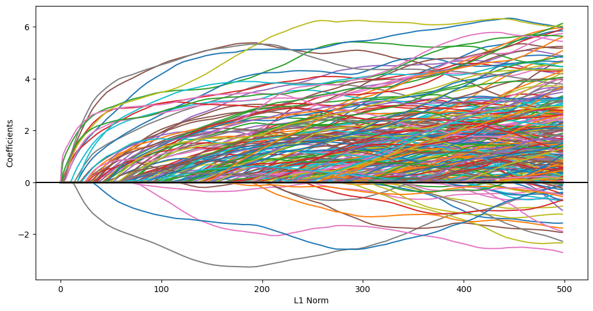

```python
l1_norm = np.sum(np.abs(lasso490.coef_path_), axis=0)
plt.figure(figsize=(12,6))
plt.plot(l1_norm, lasso490.coef_path_.T)
plt.axhline(y = 0, color='k')
plt.xlabel("L1 Norm")
plt.ylabel("Coefficients");
```

Find best $\lambda$ using cross validation.

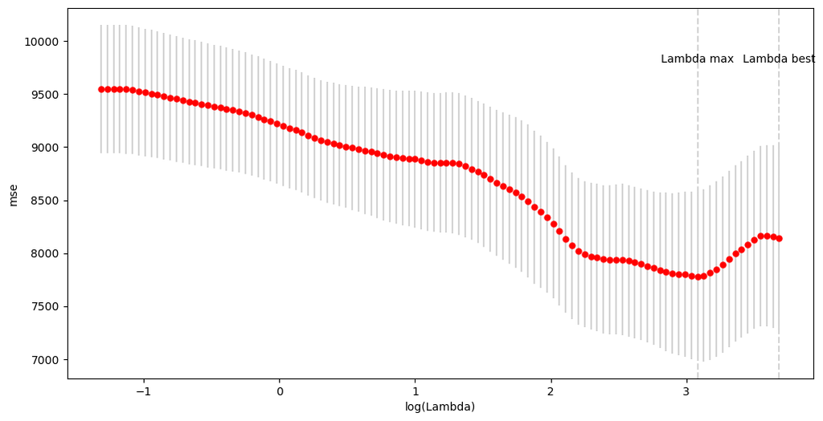

```python
plt.figure(figsize=(12,6))
plt.errorbar(np.log(lasso490.lambda_path_), -lasso490.cv_mean_score_, color='r', linestyle='None', marker='o',
             markersize=5, yerr=lasso490.cv_standard_error_, ecolor='lightgrey', capthick=2)
plt.axvline(x=np.log(lasso490.lambda_max_), linestyle='dashed', color='lightgrey')
plt.text(np.log(lasso490.lambda_max_), .95*plt.gca().get_ylim()[1], 'Lambda max', ha='center')
plt.axvline(x=np.log(lasso490.lambda_best_), linestyle='dashed', color='lightgrey')
plt.text(np.log(lasso490.lambda_best_), .95*plt.gca().get_ylim()[1], 'Lambda best', ha='center')
plt.ylabel('mse')
plt.xlabel('log(Lambda)');
```

```python
bestlam = lasso490.lambda_max_
print(bestlam)
```

```
21.80698591571144
```

Calculate mean squares prediction error for the best lambda.

```python
lasso_pred = lasso490.predict(X_test, lamb = bestlam)
lasso_MSE = np.mean((lasso_pred -y_test)**2)
print(lasso_MSE)
```

```
7688.459136966582
```

Fit lasso regression model to the entire data.  
Plot the set of true slopes used in simulation and mark slopes removed by lasso.

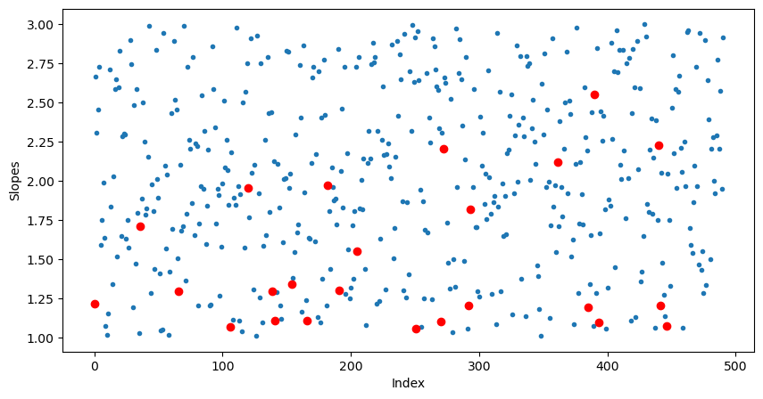

```python
out = glmnet.ElasticNet(alpha=1, n_lambda=200, scoring='mean_squared_error',
                        n_splits=10, standardize=False)
out.fit(X.iloc[:,:491],Y[:,489])
lasso_coef = out.coef_
removedSlopes = np.repeat(np.NAN, 491)
removedSlopes[lasso_coef==0] = slopesSet[:491][lasso_coef==0]
plt.figure(figsize=(10,5))
plt.plot(slopesSet[:491], ".")
plt.plot(removedSlopes, "o", color="red");
plt.xlabel('Index')
plt.ylabel('Slopes');
```

Lasso removed predictors seemingly randomly regardless of the value of slope.  
Given the way the sample was simulated (independent predictors with slopes between 1 and 3) it would be more reasonable removing none or removing the predictors with smallest slopes.

## Large number of predictors, not all of them are significant

To check how lasso regression removes predictors modify the simulated data to make some of predictors insignificant.

The previous set was simulated with slopes randomly selected between 1 and 3.  
Such selection of slopes made them all distinct from zero which was captured by the linear model.  
Now select slopes as random numbers between -0.1 and 3.  
Obviously, the slopes which are close to zero should appear as insignificant in a model fit.

```python
np.random.seed(1234567)

Epsilon = np.random.normal(0,1, size=500)
colnames = [ "X%i" %(j+1) for j in range(500)]
X = pd.DataFrame(np.random.normal(0,2, size=(500, 500)), columns=colnames)
slopesSet = np.random.uniform(low=-0.1, high=3, size=500)

Y = np.column_stack([1 + np.dot(X.iloc[:, :j], slopesSet[:j]) + Epsilon for j in range(2, 501)])
```

Separate the sample into train and test and fit lasso.

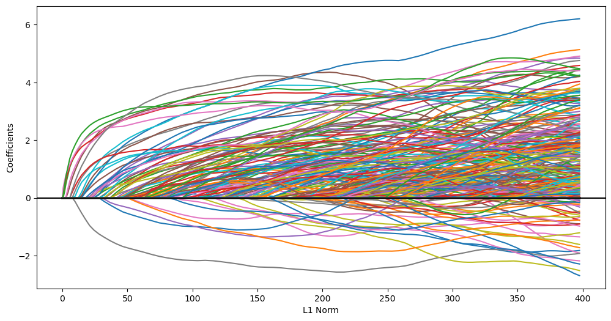

```python
X_train, X_test, y_train, y_test = train_test_split(X.iloc[:,:491], Y[:,489],
                                                    test_size=0.5, random_state=1)
lasso490 = glmnet.ElasticNet(alpha=1, n_lambda=200, scoring='mean_squared_error',
                             n_splits=10, standardize=False)
lasso490.fit(X_train, y_train)
l1_norm = np.sum(np.abs(lasso490.coef_path_), axis=0)
plt.figure(figsize=(12,6))
plt.plot(l1_norm, lasso490.coef_path_.T)
plt.axhline(y = 0, color='k')
plt.xlabel("L1 Norm")
plt.ylabel("Coefficients");
```

Select best $\lambda$ using cross validation.

```python
bestlam = lasso490.lambda_max_
print(bestlam)
```

```
9.390444596408368
```

Fit lasso to the entire sample.

```python
out = glmnet.ElasticNet(alpha=1, n_lambda=200, scoring='mean_squared_error',
                        n_splits=10, standardize=False)
out.fit(X.iloc[:,:491], Y[:,489]);
```

Find resulting coefficients.  
Plot actual slopes and mark the slopes removed by lasso.

```python
lasso_coef = out.coef_
removedSlopes = np.repeat(np.NAN, 491)
removedSlopes[lasso_coef==0] = slopesSet[:491][lasso_coef==0]
```

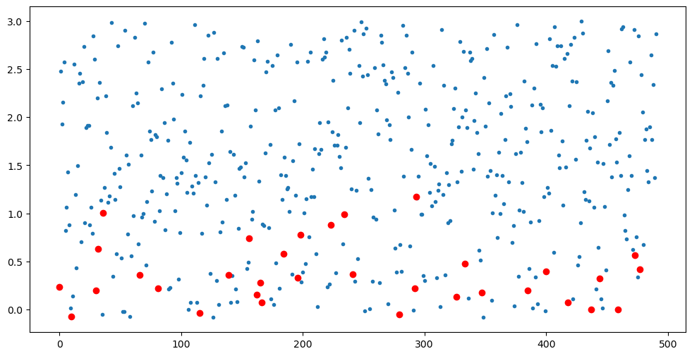

```python
plt.figure(figsize=(12,6))
plt.plot(slopesSet[:491], ".")
plt.plot(removedSlopes, "o", color="red");
```

Make the same plot marking actual slopes removed by linear model.

```python
m491 = sm.OLS(Y[:,489],sm.add_constant(X.iloc[:,:491])).fit()
```

Check the coefficients that you obtained

```python
print(m491.params[:10])
```

```
const    0.748734
X1       0.866395
X2       2.224208
X3       1.870004
X4       2.762242
X5       2.412878
X6       1.125047
X7       1.046439
X8       1.350620
X9       0.479494
dtype: float64
```

Make plot showing slopes of removed predictors.

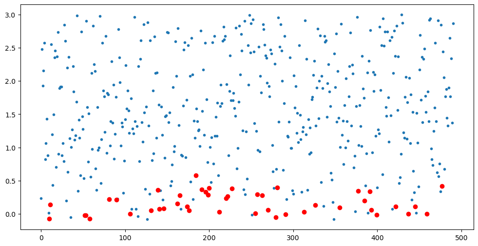

```python
eliminatedByLm = m491.pvalues[1:] > 0.05
removedSlopes = np.repeat(np.NAN, 491)
removedSlopes[eliminatedByLm] = slopesSet[:491][eliminatedByLm]

plt.figure(figsize=(12,6))
plt.plot(slopesSet[:491], ".")
plt.plot(removedSlopes, "o", color="red");
```